# Týden 3: Datové struktury a faktory

## Na zahřátí

#### úkol 1

Nejprve načtěte balík **tibble**.

```r
library(tibble)
```

#### úkol 2

Vytvořte tabulku `df` třídy *tibble*, který bude obsahovat následující proměnné (sloupce):

- `id` … hodnoty 1, 2, 3, 4 a 5 typu *integer*
- `value` … hodnoty 1.3, 1.7, 2.7, 3.15 a 17

```r
df <- tibble(id = 1:5,
             value = c(1.3, 1.7, 2.7, 3.15, 17))
df
```

| id | value |
| --- | --- |
| 1 | 1.30 |
| 2 | 1.70 |
| 3 | 2.70 |
| 4 | 3.15 |
| 5 | 17.00 |

| id <int> | value <dbl> |  |  |  |
| --- | --- | --- | --- | --- |
| 1 | 1.30 |  |  |  |
| 2 | 1.70 |  |  |  |
| 3 | 2.70 |  |  |  |
| 4 | 3.15 |  |  |  |
| 5 | 17.00 |  |  |  |

5 rows

#### úkol 3

Z tabulky `df` vyberte

- první dva řádky
- tabulku, která obsahuje jen sloupec `value`
- vektor `value`

```r
df[1:2, ]
```

| id | value |
| --- | --- |
| 1 | 1.3 |
| 2 | 1.7 |

| id <int> | value <dbl> |  |  |  |
| --- | --- | --- | --- | --- |
| 1 | 1.3 |  |  |  |
| 2 | 1.7 |  |  |  |

2 rows

```r
df[, "value"]
```

| value |
| --- |
| 1.30 |
| 1.70 |
| 2.70 |
| 3.15 |
| 17.00 |

| value <dbl> |  |  |  |  |
| --- | --- | --- | --- | --- |
| 1.30 |  |  |  |  |
| 1.70 |  |  |  |  |
| 2.70 |  |  |  |  |
| 3.15 |  |  |  |  |
| 17.00 |  |  |  |  |

5 rows

```r
df$value
```

```
[1]  1.30  1.70  2.70  3.15 17.00
```

#### úkol 4

Načtěte data uložená v souboru “exdata03.RData”.

```r
load("exdata03.RData")
```

## Opáčko z makra

Tabulka `macro` obsahuje tři proměnné:

- `time` … roky od 1990 do 2016
- `gdp_nominal` … HDP v běžných cenách v mil. Kč
- `gdp_real` … HDP ve stálých cenách roku 2010 v mil. Kč

Zdroj dat: ČSÚ.

```r
macro
```

| time | gdp_nominal | gdp_real |
| --- | --- | --- |
| 1990 | 674251 | 2734489 |
| 1991 | 869888 | 2469809 |
| 1992 | 976497 | 2414015 |
| 1993 | 1201088 | 2445728 |
| 1994 | 1370455 | 2502820 |
| 1995 | 1586447 | 2655338 |
| 1996 | 1818342 | 2767468 |
| 1997 | 1958725 | 2751011 |
| 1998 | 2146389 | 2741968 |
| 1999 | 2242417 | 2781256 |

[output cut: 17 more lines]

| time <int> | gdp_nominal <dbl> | gdp_real <dbl> |  |  |
| --- | --- | --- | --- | --- |
| 1990 | 674251 | 2734489 |  |  |
| 1991 | 869888 | 2469809 |  |  |
| 1992 | 976497 | 2414015 |  |  |
| 1993 | 1201088 | 2445728 |  |  |
| 1994 | 1370455 | 2502820 |  |  |
| 1995 | 1586447 | 2655338 |  |  |
| 1996 | 1818342 | 2767468 |  |  |
| 1997 | 1958725 | 2751011 |  |  |
| 1998 | 2146389 | 2741968 |  |  |
| 1999 | 2242417 | 2781256 |  |  |

Next

123

Previous

1-10 of 27 rows

#### úkol 1

Přidejte do tabulky následující proměnné:

- `deflator` … deflátor HDP – spočítáte jako $Y_t / y_t \times 100$ pro $\forall t$, kde $Y_t$ je HDP v běžných cenách a $y_t$ HDP ve stálých cenách v čase $t$
- `inflation` … míru inflace – míra inflace v roce $t$ je $P_t / P_{t-1} - 1$, kde $P_t$ je hodnota deflátoru v roce $t$
- `real_growth` … míru růstu reálného HDP – míra růstu v čase $t$ je $y_t / y_{t-1} - 1$

Pozor! Proměnné `inflation` a `real_growth` mají jinou délku než ostatní vektory. Vyřešte to tak, abyste neztratili žádná data.

```r
macro$deflator <- macro$gdp_nominal / macro$gdp_real * 100
macro$inflation <- c(NA, macro$deflator[-1] / macro$deflator[-nrow(macro)] - 1)
macro$real_growth <- c(NA, macro$gdp_real[-1] / macro$gdp_real[-nrow(macro)] - 1)
macro
```

| time | gdp_nominal | gdp_real | deflator | inflation | real_growth |
| --- | --- | --- | --- | --- | --- |
| 1990 | 674251 | 2734489 | 24.65729 | NA | NA |
| 1991 | 869888 | 2469809 | 35.22086 | 0.4284154943 | -0.096793222 |
| 1992 | 976497 | 2414015 | 40.45116 | 0.1484999432 | -0.022590411 |
| 1993 | 1201088 | 2445728 | 49.10963 | 0.2140476240 | 0.013137035 |
| 1994 | 1370455 | 2502820 | 54.75643 | 0.1149836284 | 0.023343561 |
| 1995 | 1586447 | 2655338 | 59.74558 | 0.0911151708 | 0.060938461 |
| 1996 | 1818342 | 2767468 | 65.70417 | 0.0997328680 | 0.042228146 |
| 1997 | 1958725 | 2751011 | 71.20019 | 0.0836478588 | -0.005946591 |
| 1998 | 2146389 | 2741968 | 78.27914 | 0.0994232384 | -0.003287155 |
| 1999 | 2242417 | 2781256 | 80.62606 | 0.0299813479 | 0.014328395 |

[output cut: 17 more lines]

| time <int> | gdp_nominal <dbl> | gdp_real <dbl> | deflator <dbl> | inflation <dbl> | real_growth <dbl> |
| --- | --- | --- | --- | --- | --- |
| 1990 | 674251 | 2734489 | 24.65729 | NA | NA |
| 1991 | 869888 | 2469809 | 35.22086 | 0.4284154943 | -0.096793222 |
| 1992 | 976497 | 2414015 | 40.45116 | 0.1484999432 | -0.022590411 |
| 1993 | 1201088 | 2445728 | 49.10963 | 0.2140476240 | 0.013137035 |
| 1994 | 1370455 | 2502820 | 54.75643 | 0.1149836284 | 0.023343561 |
| 1995 | 1586447 | 2655338 | 59.74558 | 0.0911151708 | 0.060938461 |
| 1996 | 1818342 | 2767468 | 65.70417 | 0.0997328680 | 0.042228146 |
| 1997 | 1958725 | 2751011 | 71.20019 | 0.0836478588 | -0.005946591 |
| 1998 | 2146389 | 2741968 | 78.27914 | 0.0994232384 | -0.003287155 |
| 1999 | 2242417 | 2781256 | 80.62606 | 0.0299813479 | 0.014328395 |

Next

123

Previous

1-10 of 27 rows

#### úkol 2

Vykreslete do grafu vývoj inflace a reálného růstu v čase.

```r
plot(macro$time, macro$inflation,
     type = "l", ylim = range(c(macro$inflation, macro$real_growth), na.rm = TRUE))
lines(macro$time, macro$real_growth, col = "red")
```

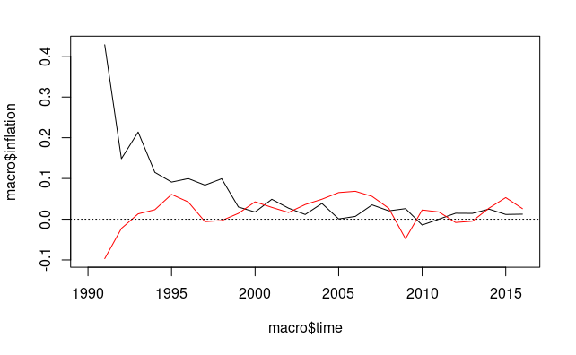

```r
abline(h = 0, lty = 3)
```

### úkol 3

Spočítejte korelaci inflace a růstu reálného HDP v čase pomocí funkce `cor()`; chybějících hodnot se zbavíte parametrem `use = "complete.obs"`.

```r
cor(macro$inflation, macro$real_growth, use = "complete.obs")
```

```
[1] -0.6315394
```

## Jestli přivedeš domů nějakou obezitu…

Tabulka `experiment` (třída *tibble*) obsahuje data o subjektech nějakého lékařského experimentu. Sloupce tabulky mají následující význam:

- `id` … jednoznačné identifikační číslo subjektu
- `name` … jméno subjektu
- `height` … výška subjektu
- `weight` … váha subjektu

```r
experiment
```

| id | name | height | weight |
| --- | --- | --- | --- |
| 1 | Valérie | 176 | 121 |
| 2 | Gabriela | 195 | 95 |
| 3 | Nina | 201 | 115 |
| 4 | Miloslava | 174 | 96 |
| 5 | Julius | 157 | 53 |
| 6 | Jitka | 161 | 61 |
| 7 | Ignác | 187 | 119 |
| 8 | Antonín | 162 | 72 |
| 9 | Jana | 194 | 85 |
| 10 | Robin | 203 | 74 |

[output cut: 332 more lines]

| id <int> | name <chr> | height <int> | weight <int> |  |
| --- | --- | --- | --- | --- |
| 1 | Valérie | 176 | 121 |  |
| 2 | Gabriela | 195 | 95 |  |
| 3 | Nina | 201 | 115 |  |
| 4 | Miloslava | 174 | 96 |  |
| 5 | Julius | 157 | 53 |  |
| 6 | Jitka | 161 | 61 |  |
| 7 | Ignác | 187 | 119 |  |
| 8 | Antonín | 162 | 72 |  |
| 9 | Jana | 194 | 85 |  |
| 10 | Robin | 203 | 74 |  |

Next

123456

...

35

Previous

1-10 of 342 rows

#### úkol 1

Zjistěte, kolik máme pozorování.

```r
pocet_pozorovani <- nrow(experiment)
pocet_pozorovani
```

```
[1] 342
```

#### úkol 2

Přidejte do tabulky proměnnou (sloupec) `bmi`, která bude obsahovat BMI jednotlivých subjektů. BMI vypočítáte jako $w/h^2$, kde $w$ je váha v kg a $h$ je výška v metrech.

```r
experiment$bmi <- experiment$weight / (experiment$height / 100) ^ 2
experiment
```

| id | name | height | weight | bmi |
| --- | --- | --- | --- | --- |
| 1 | Valérie | 176 | 121 | 39.06250 |
| 2 | Gabriela | 195 | 95 | 24.98356 |
| 3 | Nina | 201 | 115 | 28.46464 |
| 4 | Miloslava | 174 | 96 | 31.70828 |
| 5 | Julius | 157 | 53 | 21.50189 |
| 6 | Jitka | 161 | 61 | 23.53304 |
| 7 | Ignác | 187 | 119 | 34.03014 |
| 8 | Antonín | 162 | 72 | 27.43484 |
| 9 | Jana | 194 | 85 | 22.58476 |
| 10 | Robin | 203 | 74 | 17.95724 |

[output cut: 332 more lines]

| id <int> | name <chr> | height <int> | weight <int> | bmi <dbl> |
| --- | --- | --- | --- | --- |
| 1 | Valérie | 176 | 121 | 39.06250 |
| 2 | Gabriela | 195 | 95 | 24.98356 |
| 3 | Nina | 201 | 115 | 28.46464 |
| 4 | Miloslava | 174 | 96 | 31.70828 |
| 5 | Julius | 157 | 53 | 21.50189 |
| 6 | Jitka | 161 | 61 | 23.53304 |
| 7 | Ignác | 187 | 119 | 34.03014 |
| 8 | Antonín | 162 | 72 | 27.43484 |
| 9 | Jana | 194 | 85 | 22.58476 |
| 10 | Robin | 203 | 74 | 17.95724 |

Next

123456

...

35

Previous

1-10 of 342 rows

#### úkol 3

Přidejte do tabulky proměnnou `gender`, která bude obsahovat pohlaví subjektů. Postupujte ve třech krocích:

1. Výraz `stringr::str_detect(experiment$name, "[ae]$")` vrátí hodnotu `TRUE` pro všechna jména, která končí na “a” nebo “e” a `FALSE` pro ostatní. Většina ženských jmen tak bude mít hodnotu `TRUE` a všechna mužská jména hodnotu `FALSE`.
2. Převeďte logické hodnoty na faktor tak, aby jeho hodnoty byly “female” a “male” (v tomto pořadí).
3. Je potřeba opravit hodnotu pro jména “Miriam” a “Ingrid”.
4. Změňte pořadí proměnných v tabulce tak, aby bylo `id`, `name`, `gender`, `height`, `weight` a `bmi`.

```r
# Miriam, Ingrid
experiment$gender <- stringr::str_detect(experiment$name, "[ae]$")
experiment$gender <- factor(experiment$gender, levels = c(TRUE, FALSE), labels = c("female", "male"))
experiment$gender[experiment$name == "Miriam"] <- "female"
experiment[experiment$name == "Ingrid", "gender"] <- "female"
# nebo naráz
experiment$gender[experiment$name %in% c("Miriam", "Ingrid")] <- "female"
experiment <- experiment[, c("id", "name", "gender", "height", "weight", "bmi")]
experiment
```

| id | name | gender | height | weight | bmi |
| --- | --- | --- | --- | --- | --- |
| 1 | Valérie | female | 176 | 121 | 39.06250 |
| 2 | Gabriela | female | 195 | 95 | 24.98356 |
| 3 | Nina | female | 201 | 115 | 28.46464 |
| 4 | Miloslava | female | 174 | 96 | 31.70828 |
| 5 | Julius | male | 157 | 53 | 21.50189 |
| 6 | Jitka | female | 161 | 61 | 23.53304 |
| 7 | Ignác | male | 187 | 119 | 34.03014 |
| 8 | Antonín | male | 162 | 72 | 27.43484 |
| 9 | Jana | female | 194 | 85 | 22.58476 |
| 10 | Robin | male | 203 | 74 | 17.95724 |

[output cut: 332 more lines]

| id <int> | name <chr> | gender <fctr> | height <int> | weight <int> | bmi <dbl> |
| --- | --- | --- | --- | --- | --- |
| 1 | Valérie | female | 176 | 121 | 39.06250 |
| 2 | Gabriela | female | 195 | 95 | 24.98356 |
| 3 | Nina | female | 201 | 115 | 28.46464 |
| 4 | Miloslava | female | 174 | 96 | 31.70828 |
| 5 | Julius | male | 157 | 53 | 21.50189 |
| 6 | Jitka | female | 161 | 61 | 23.53304 |
| 7 | Ignác | male | 187 | 119 | 34.03014 |
| 8 | Antonín | male | 162 | 72 | 27.43484 |
| 9 | Jana | female | 194 | 85 | 22.58476 |
| 10 | Robin | male | 203 | 74 | 17.95724 |

Next

123456

...

35

Previous

1-10 of 342 rows

#### úkol 4

Spočítejte medián BMI pro celý vzorek, jen pro muže a jen pro ženy.

```r
median(experiment$bmi)
```

```
[1] 28.13169
```

```r
median(experiment$bmi[experiment$gender == "male"])
```

```
[1] 27.43484
```

```r
median(experiment$bmi[experiment$gender == "female"])
```

```
[1] 28.85921
```

#### úkol 5

Přidejte do tabulky proměnnou `obese`, která bude obsahovat logickou hodnotu `TRUE` u subjektů, kterém mají BMI$\geq 30$.

```r
experiment$obese <- experiment$bmi >= 30
experiment
```

| id | name | gender | height | weight | bmi | obese |
| --- | --- | --- | --- | --- | --- | --- |
| 1 | Valérie | female | 176 | 121 | 39.06250 | TRUE |
| 2 | Gabriela | female | 195 | 95 | 24.98356 | FALSE |
| 3 | Nina | female | 201 | 115 | 28.46464 | FALSE |
| 4 | Miloslava | female | 174 | 96 | 31.70828 | TRUE |
| 5 | Julius | male | 157 | 53 | 21.50189 | FALSE |
| 6 | Jitka | female | 161 | 61 | 23.53304 | FALSE |
| 7 | Ignác | male | 187 | 119 | 34.03014 | TRUE |
| 8 | Antonín | male | 162 | 72 | 27.43484 | FALSE |
| 9 | Jana | female | 194 | 85 | 22.58476 | FALSE |
| 10 | Robin | male | 203 | 74 | 17.95724 | FALSE |

[output cut: 332 more lines]

| id <int> | name <chr> | gender <fctr> | height <int> | weight <int> | bmi <dbl> | obese <lgl> |
| --- | --- | --- | --- | --- | --- | --- |
| 1 | Valérie | female | 176 | 121 | 39.06250 | TRUE |
| 2 | Gabriela | female | 195 | 95 | 24.98356 | FALSE |
| 3 | Nina | female | 201 | 115 | 28.46464 | FALSE |
| 4 | Miloslava | female | 174 | 96 | 31.70828 | TRUE |
| 5 | Julius | male | 157 | 53 | 21.50189 | FALSE |
| 6 | Jitka | female | 161 | 61 | 23.53304 | FALSE |
| 7 | Ignác | male | 187 | 119 | 34.03014 | TRUE |
| 8 | Antonín | male | 162 | 72 | 27.43484 | FALSE |
| 9 | Jana | female | 194 | 85 | 22.58476 | FALSE |
| 10 | Robin | male | 203 | 74 | 17.95724 | FALSE |

Next

123456

...

35

Previous

1-10 of 342 rows

#### úkol 6

Vytvořte tabulku `obese`, který bude obsahovat pouze ty subjekty, které jsou obézní. Odstraňte z tabulky (v něm zbytečnou) proměnnou `obese`.

```r
obese <- experiment[experiment$obese, ]
obese$obese <- NULL
obese
```

| id | name | gender | height | weight | bmi |
| --- | --- | --- | --- | --- | --- |
| 1 | Valérie | female | 176 | 121 | 39.06250 |
| 4 | Miloslava | female | 174 | 96 | 31.70828 |
| 7 | Ignác | male | 187 | 119 | 34.03014 |
| 11 | Igor | male | 165 | 99 | 36.36364 |
| 12 | Alice | female | 166 | 84 | 30.48338 |
| 13 | Jeroným | male | 153 | 120 | 51.26233 |
| 17 | Dušan | male | 159 | 104 | 41.13761 |
| 20 | Věroslav | male | 201 | 122 | 30.19727 |
| 23 | Hana | female | 187 | 118 | 33.74417 |
| 25 | Veronika | female | 149 | 94 | 42.34044 |

[output cut: 137 more lines]

| id <int> | name <chr> | gender <fctr> | height <int> | weight <int> | bmi <dbl> |
| --- | --- | --- | --- | --- | --- |
| 1 | Valérie | female | 176 | 121 | 39.06250 |
| 4 | Miloslava | female | 174 | 96 | 31.70828 |
| 7 | Ignác | male | 187 | 119 | 34.03014 |
| 11 | Igor | male | 165 | 99 | 36.36364 |
| 12 | Alice | female | 166 | 84 | 30.48338 |
| 13 | Jeroným | male | 153 | 120 | 51.26233 |
| 17 | Dušan | male | 159 | 104 | 41.13761 |
| 20 | Věroslav | male | 201 | 122 | 30.19727 |
| 23 | Hana | female | 187 | 118 | 33.74417 |
| 25 | Veronika | female | 149 | 94 | 42.34044 |

Next

123456

...

15

Previous

1-10 of 147 rows

#### úkol 7

Seřaďte subjekty v tabulce `obese` od subjektu s nejvyšším BMI po subjekt s nejnižším BMI. Vypište pouze 5 nejobéznějších subjektů.

```r
obese <- obese[order(obese$bmi, decreasing = TRUE), ]
# nebo
obese <- obese[order(-obese$bmi), ]

head(obese, n = 5)
```

| id | name | gender | height | weight | bmi |
| --- | --- | --- | --- | --- | --- |
| 200 | Horymír | male | 149 | 123 | 55.40291 |
| 312 | Miriam | female | 150 | 122 | 54.22222 |
| 217 | Izabela | female | 149 | 119 | 53.60119 |
| 242 | Kamila | female | 153 | 124 | 52.97108 |
| 308 | Silvie | female | 151 | 120 | 52.62927 |

| id <int> | name <chr> | gender <fctr> | height <int> | weight <int> | bmi <dbl> |
| --- | --- | --- | --- | --- | --- |
| 200 | Horymír | male | 149 | 123 | 55.40291 |
| 312 | Miriam | female | 150 | 122 | 54.22222 |
| 217 | Izabela | female | 149 | 119 | 53.60119 |
| 242 | Kamila | female | 153 | 124 | 52.97108 |
| 308 | Silvie | female | 151 | 120 | 52.62927 |

5 rows

#### úkol 8

Experiment bude probíhat pouze na obézních subjektech. Potřebujete je rozdělit do dvou skupin: na treatmentovou a kontrolní skupinu. Do treatmentové skupiny chcete vybrat náhodně polovinu subjektů; zbytek bude kontrolní skupina. Informace o tom, do jaké skupiny subjekt patří, bude obsahovat proměnná `group`, která bude faktor o dvou hodnotách: “treatment” a “control”.

Nápověda:

- výraz `sample(N, n)`, kde $N$ je jedno celé číslo, vrátí náhodný výběr $n$ hodnot z čísel $1, 2, \ldots, N$ bez opakování
- výraz `sample(v, n)`, kde $v$ je vektor délky aspoň 2, vrátí náhodný výběř $n$ hodnot z vektoru $v$ bez opakování

Pozor: Protože rozdělujeme subjekty do skupin náhodně, při každém běhu vyjdou jiné výsledky – leda, že bychom nastavili počáteční stav generátoru náhodných čísel pomocí funkce `set.seed()`.

```r
# varianta 1
obese$group <- FALSE
smpl <- sample(nrow(obese), nrow(obese) / 2)
obese$group[smpl] <- TRUE
obese$group <- factor(obese$group, levels = c(TRUE, FALSE), labels = c("control", "treatment"))
# varianta 2
obese$group <- sample(rep_len(1:2, nrow(obese)), nrow(obese))
obese$group <- factor(obese$group, levels = 1:2, labels = c("control", "treatment"))
# varianta 3
obese$group <- factor(sample(rep_len(c("control", "treatment"), nrow(obese)),
                             nrow(obese)))
# výpis výsledku
obese
```

| id | name | gender | height | weight | bmi | group |
| --- | --- | --- | --- | --- | --- | --- |
| 200 | Horymír | male | 149 | 123 | 55.40291 | control |
| 312 | Miriam | female | 150 | 122 | 54.22222 | control |
| 217 | Izabela | female | 149 | 119 | 53.60119 | treatment |
| 242 | Kamila | female | 153 | 124 | 52.97108 | treatment |
| 308 | Silvie | female | 151 | 120 | 52.62927 | treatment |
| 324 | Klement | male | 155 | 126 | 52.44537 | treatment |
| 275 | Bohuslav | male | 154 | 124 | 52.28538 | control |
| 293 | Berta | female | 151 | 118 | 51.75212 | control |
| 219 | Anastázie | female | 152 | 119 | 51.50623 | control |
| 13 | Jeroným | male | 153 | 120 | 51.26233 | treatment |

[output cut: 137 more lines]

| id <int> | name <chr> | gender <fctr> | height <int> | weight <int> | bmi <dbl> | group <fctr> |
| --- | --- | --- | --- | --- | --- | --- |
| 200 | Horymír | male | 149 | 123 | 55.40291 | control |
| 312 | Miriam | female | 150 | 122 | 54.22222 | control |
| 217 | Izabela | female | 149 | 119 | 53.60119 | treatment |
| 242 | Kamila | female | 153 | 124 | 52.97108 | treatment |
| 308 | Silvie | female | 151 | 120 | 52.62927 | treatment |
| 324 | Klement | male | 155 | 126 | 52.44537 | treatment |
| 275 | Bohuslav | male | 154 | 124 | 52.28538 | control |
| 293 | Berta | female | 151 | 118 | 51.75212 | control |
| 219 | Anastázie | female | 152 | 119 | 51.50623 | control |
| 13 | Jeroným | male | 153 | 120 | 51.26233 | treatment |

Next

123456

...

15

Previous

1-10 of 147 rows

#### úkol 9

Zkontrolujte párování svých skupin:

- zda jsou obě skupiny zhruba stejně velké
- zda obě skupiny mají stejný podíl mužů a žen – pomocí funkce `prop.test()`
- zda mají obě skupiny stejnou střední hodnotu BMI – pomocí funkce `t.test()`

Nápověda:

- funkce `prop.test(x, n)` spočítá test shodnosti proporcí; `x` je vektor počtu úspěšných pokusů v jednotlivých skupinách, `n` je počet pozorování v jednotlivých skupinách; “úspěch” je být ženou
- funkce `t.test()` spočítá test shody střední hodnoty (za předpokladu normality a různých rozptylů); dvě verze interface:
  - `t.test(x, y)` shoda střední hodnoty ve vektorech `x` a `y`
  - `t.test(formula, data)` totéž pomocí formule a dat; formule `velična ~ grupovací_proměnná`)

```r
# počet pozorování ve skupinách
treatment_all <- nrow(obese[obese$group == "treatment", ])
control_all <- sum(obese$group == "control")
c(treatment = treatment_all, control = control_all)
```

```
treatment   control
       73        74
```

```r
# počet žen ve skupinách
treament_females <- nrow(obese[obese$group == "treatment" & obese$gender == "female", ])
control_females <- sum(obese$group == "control" & obese$gender == "female")
# podíl žen ve skupinách
c(treatment = treament_females / treatment_all,
  control = control_females / control_all)
```

```
treatment   control
0.5205479 0.4729730
```

```r
# test shodného podílu žen
prop.test(c(treament_females, control_females), c(treatment_all, control_all))
```

```
    2-sample test for equality of proportions with continuity correction

data:  c(treament_females, control_females) out of c(treatment_all, control_all)
X-squared = 0.16962, df = 1, p-value = 0.6804
alternative hypothesis: two.sided
95 percent confidence interval:
 -0.1275038  0.2226538
sample estimates:
   prop 1    prop 2
0.5205479 0.4729730
```

```r
# průměrné BMI ve skupinách
c(treatment = mean(obese$bmi[obese$group == "treatment"]),
  control = mean(obese$bmi[obese$group == "control"]))
```

```
treatment   control
 38.92742  38.43557
```

```r
# t-test (dvě alternativy zadání)
t.test(obese$bmi[obese$group == "treatment"], obese$bmi[obese$group == "control"])
```

```
    Welch Two Sample t-test

data:  obese$bmi[obese$group == "treatment"] and obese$bmi[obese$group == "control"]
t = 0.4615, df = 141.46, p-value = 0.6451
alternative hypothesis: true difference in means is not equal to 0
95 percent confidence interval:
 -1.615005  2.598702
sample estimates:
mean of x mean of y
 38.92742  38.43557
```

```r
t.test(bmi ~ group, data = obese)
```

```
    Welch Two Sample t-test

data:  bmi by group
t = -0.4615, df = 141.46, p-value = 0.6451
alternative hypothesis: true difference in means is not equal to 0
95 percent confidence interval:
 -2.598702  1.615005
sample estimates:
  mean in group control mean in group treatment
               38.43557                38.92742
```

## Jste na seznamu

Padouch Syndrom si vede seznam cílů, které chce zlikvidovat. Seznam je skutečně seznam. Každá z jeho položek obsahuje tři informace: tajnou identitu superhrdiny, jeho bydliště a zda byl zničen.

#### úkol 1

Vytvořte seznam `kill_list`, který bude obsahovat následující položky:

| tajná identita | bydliště | zničen |
| --- | --- | --- |
| Palzrak | Grave Town 3 | TRUE |
| Pan Úžasňák | Insurance Hill 121 | FALSE |
| Elastička | NA | FALSE |

```r
kill_list <- list(list(name = "Palzrak", home = "Grave Town 3", eliminated = TRUE),
                  list(name = "Mr. Incredible", home = "Insurance Hill 121", eliminated = FALSE),
                  list(name = "Elastigirl", home = NA_character_, eliminated = FALSE))
kill_list
```

```
[[1]]
[[1]]$name
[1] "Palzrak"

[[1]]$home
[1] "Grave Town 3"

[[1]]$eliminated
[1] TRUE


[[2]]
[[2]]$name
[1] "Mr. Incredible"

[[2]]$home
[1] "Insurance Hill 121"

[[2]]$eliminated
[1] FALSE


[[3]]
[[3]]$name
[1] "Elastigirl"

[[3]]$home
[1] NA

[[3]]$eliminated
[1] FALSE
```

#### úkol 2

- vyberte ze seznamu `kill_list` seznam s údaji o panu Úžasňákovi
- vyberte ze seznamu `kill_list` seznam s bydlištěm pana Úžasňáka
- vyberte ze seznamu `kill_list` vektor s bydlištěm pana Úžasňáka

```r
kill_list[[2]]
```

```
$name
[1] "Mr. Incredible"

$home
[1] "Insurance Hill 121"

$eliminated
[1] FALSE
```

```r
kill_list[[2]][2]
```

```
$home
[1] "Insurance Hill 121"
```

```r
kill_list[[2]][[2]]
```

```
[1] "Insurance Hill 121"
```

#### úkol 3

Navrhněte lepší datovou strukturu pro uložení dat hrdinů určených ke zničení a vyberte z ní bydliště pana Úžasňáka.

```r
# tabulka
kill_table <- tibble(name = c("Palzrak", "Mr. Incredible", "Elastigirl"),
                     home = c("Grave Town 3", "Insurance Hill 121", NA),
                     eliminated = c(TRUE, FALSE, FALSE))
# alternativně zadaný po řádcích
kill_table <- tribble(~name, ~home, ~eliminated,
                      "Palzrak", "Grave Town 3", TRUE,
                      "Mr. Incredible", "Insurance Hill 121", FALSE,
                      "Elastigirl", NA, FALSE)
# výběr -- výsledkem je tabulka
kill_table[kill_table$name == "Mr. Incredible", "home"]
```

| home |
| --- |
| Insurance Hill 121 |

| home <chr> |  |  |  |  |
| --- | --- | --- | --- | --- |
| Insurance Hill 121 |  |  |  |  |

1 row

```r
# výběr -- výsledkem je vektor s jednou hodnotou
kill_table$home[kill_table$name == "Mr. Incredible"]
```

```
[1] "Insurance Hill 121"
```

## Poznámka

Později vás naučíme velkou část těchto operací dělat pohodlněji pomocí balíku **dplyr**. Přesto se však vyplatí umět i tento jednodušší přístup, a to zejména, když potřebujete upravovat data přímo v tabulkách.